# Teaching Social Work Statistics with R

Wes Furlong

### Call the packages we’ll use for the analysis:

tidyverse, mosaic, janitor, data.table, DataExplorer, SmartEDA, and psych.

### Load the dataset:

```r
schools <- read.csv("asheville_school_data.csv", stringsAsFactors = FALSE)
schools <- schools %>%
  clean_names()
schools <- schools %>% rename(name = i_name)
```

### Let’s subset a few variables and take a look at the data:

```r
schools_1 <- schools %>%
  select(name, type, stud_teach_ratio, free_dis_lunch, enrollment, district, title_1, avg_score_2018, rank_change)

str(schools_1)
```

```
## 'data.frame':    61 obs. of  9 variables:
##  $ name            : chr  "Asheville High" "Asheville Middle" "Avery's Creek Elementary" "Barnardsville Elementary" ...
##  $ type            : chr  "Public" "Public" "Public" "Public" ...
##  $ stud_teach_ratio: num  11.4 13.6 14.3 11.6 13.1 15.2 13.1 14 14.5 16.5 ...
##  $ free_dis_lunch  : num  0.33 0.43 0.68 0.66 0.6 0.54 0.55 0.74 0.35 0.44 ...
##  $ enrollment      : int  1021 796 582 146 273 217 400 422 573 493 ...
##  $ district        : chr  "Asheville City Schools" "Asheville City Schools" "Buncombe County Schools" "Buncombe County Schools" ...
##  $ title_1         : chr  "No" "No" "Yes" "Yes" ...
##  $ avg_score_2018  : num  61.9 59.5 51.6 72.2 55 68.1 NA 50.7 83 66.2 ...
##  $ rank_change     : chr  "23" "-45" "123" "234" ...
```

```r
describe(schools_1)
```

```
##                  vars  n   mean     sd median trimmed    mad     min
## name*               1 61    NaN     NA     NA     NaN     NA     Inf
## type*               2 61    NaN     NA     NA     NaN     NA     Inf
## stud_teach_ratio    3 56  14.79   2.40  14.95   14.72   1.78    9.10
## free_dis_lunch      4 56   0.53   0.19   0.50    0.52   0.19    0.09
## enrollment          5 56 549.27 311.54 512.50  512.78 232.77   60.00
## district*           6 61    NaN     NA     NA     NaN     NA     Inf
## title_1*            7 61    NaN     NA     NA     NaN     NA     Inf
## avg_score_2018      8 45  61.28  20.20  63.80   63.14  14.23    6.70
## rank_change*        9 61  21.39 153.11  11.50   17.56  88.21 -448.00
##                      max  range  skew kurtosis    se
## name*               -Inf   -Inf    NA       NA    NA
## type*               -Inf   -Inf    NA       NA    NA
## stud_teach_ratio   24.40   15.3  0.83     3.57  0.32
## free_dis_lunch      0.99    0.9  0.40     0.12  0.02
## enrollment       1619.00 1559.0  1.21     1.71 41.63
## district*           -Inf   -Inf    NA       NA    NA
## title_1*            -Inf   -Inf    NA       NA    NA
## avg_score_2018     91.10   84.4 -0.89     0.45  3.01
## rank_change*      419.00  867.0  0.04     2.27 19.60
```

### Examine the categorical variables:

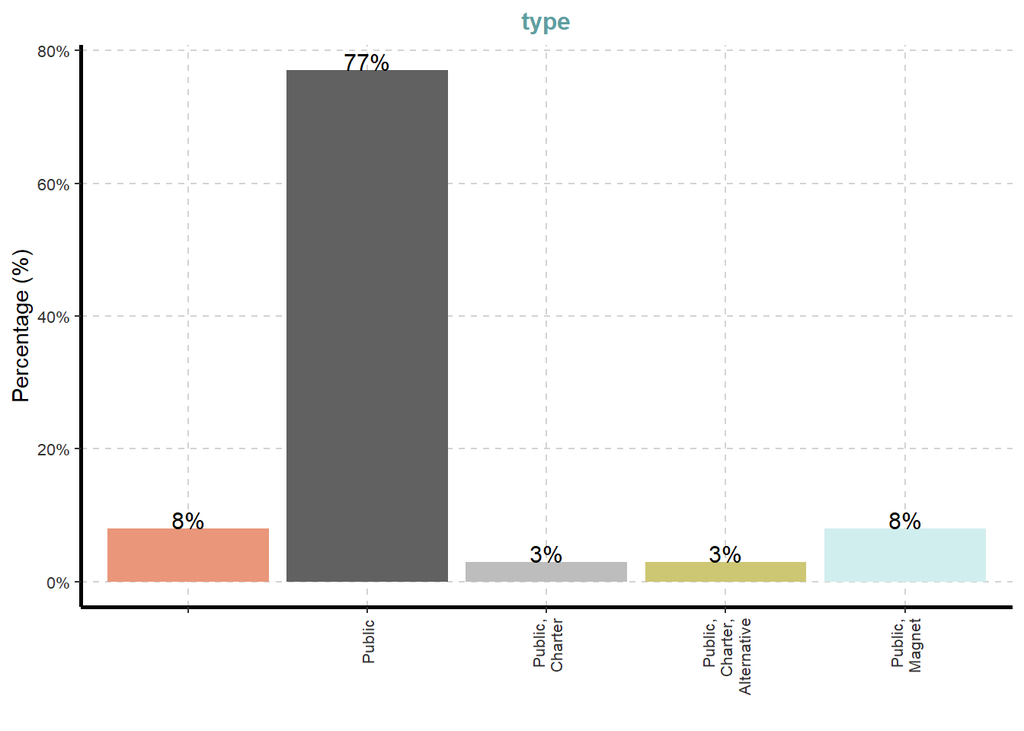

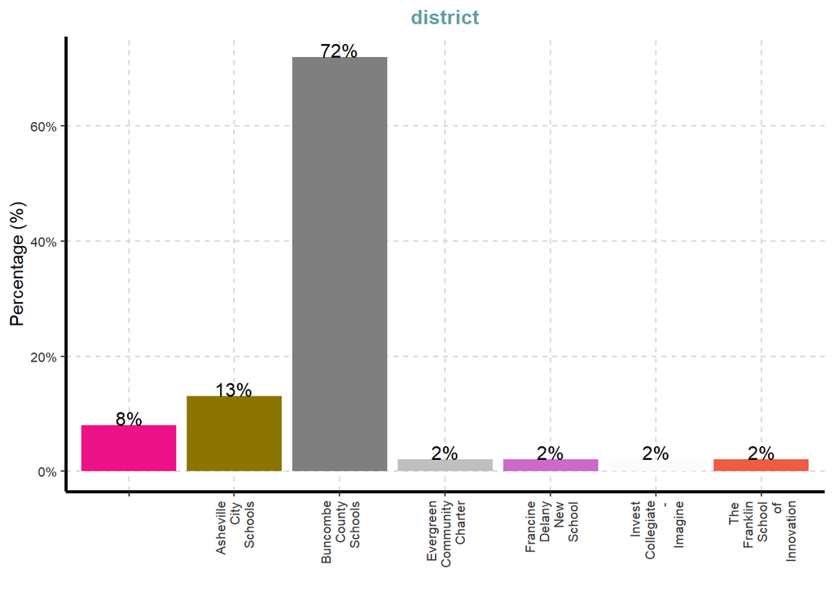

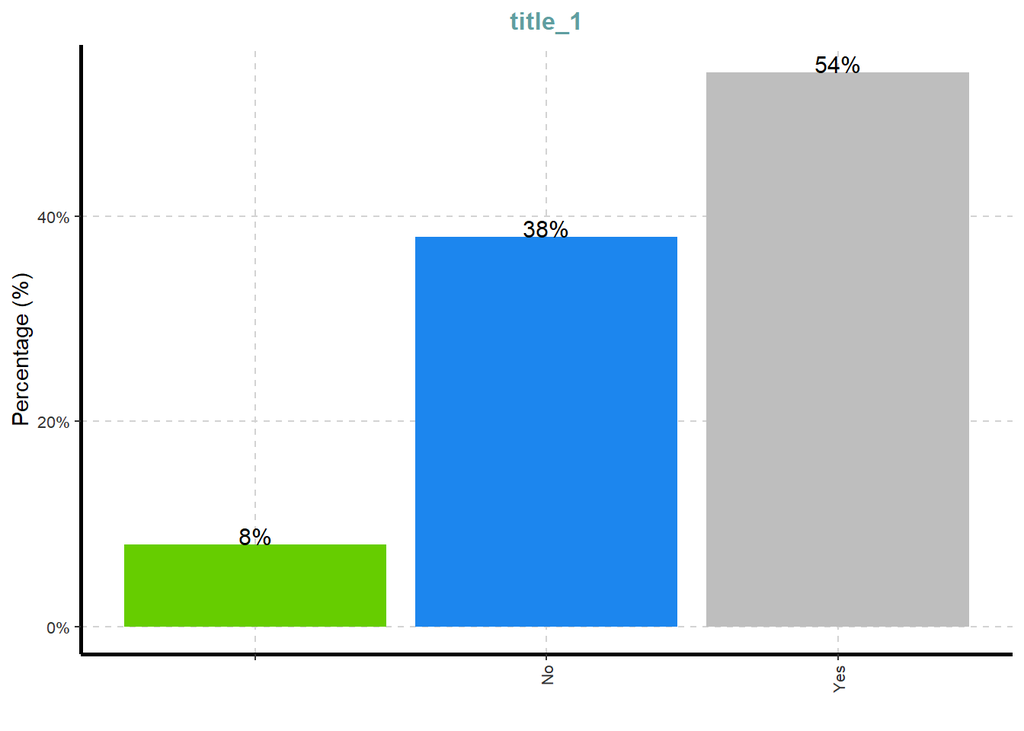

```r
ExpCatViz(schools_1)
```

### Examine the distribution of the numeric variables:

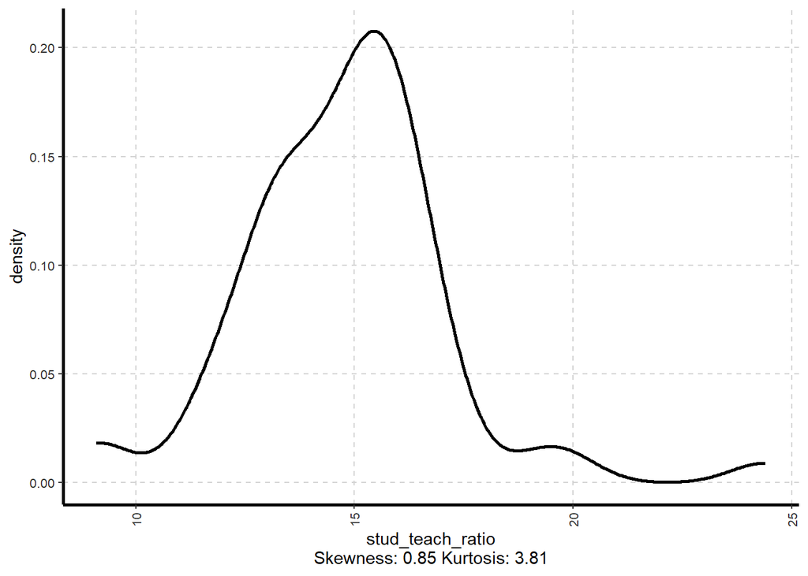

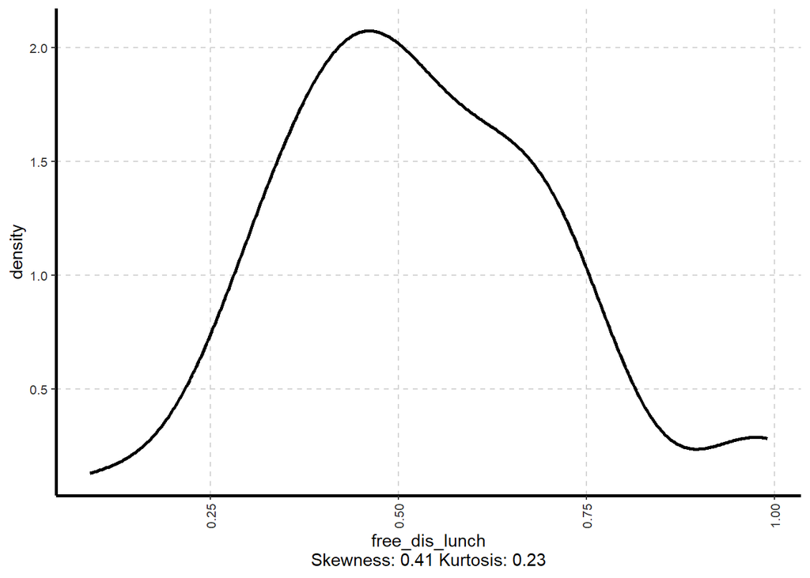

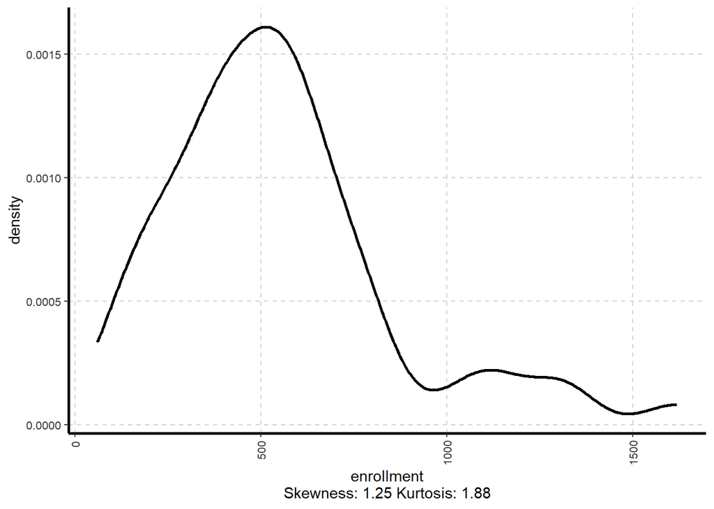

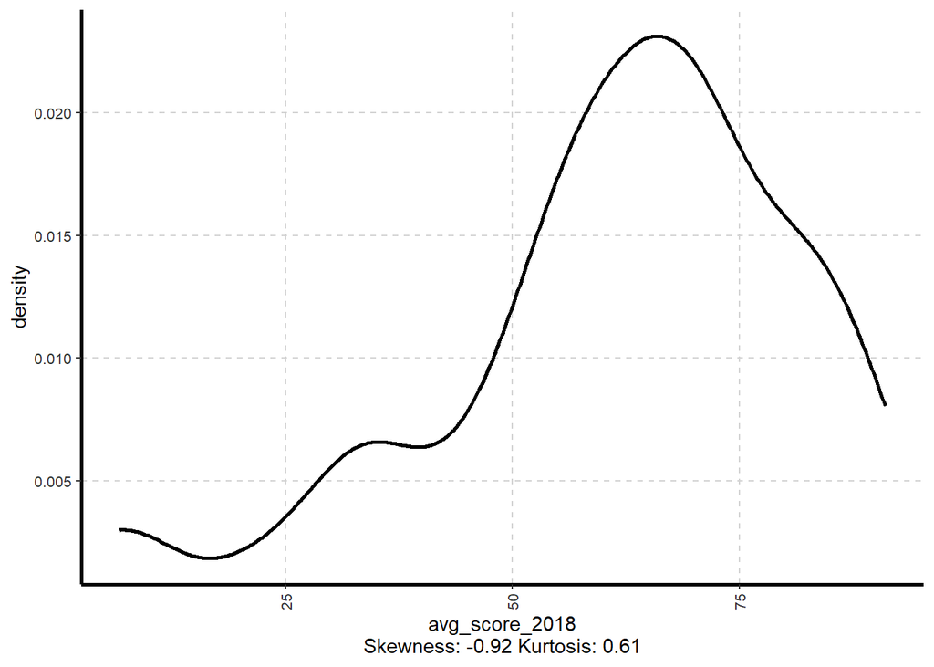

```r
ExpNumViz(schools_1)
```

### Examine the missing values:

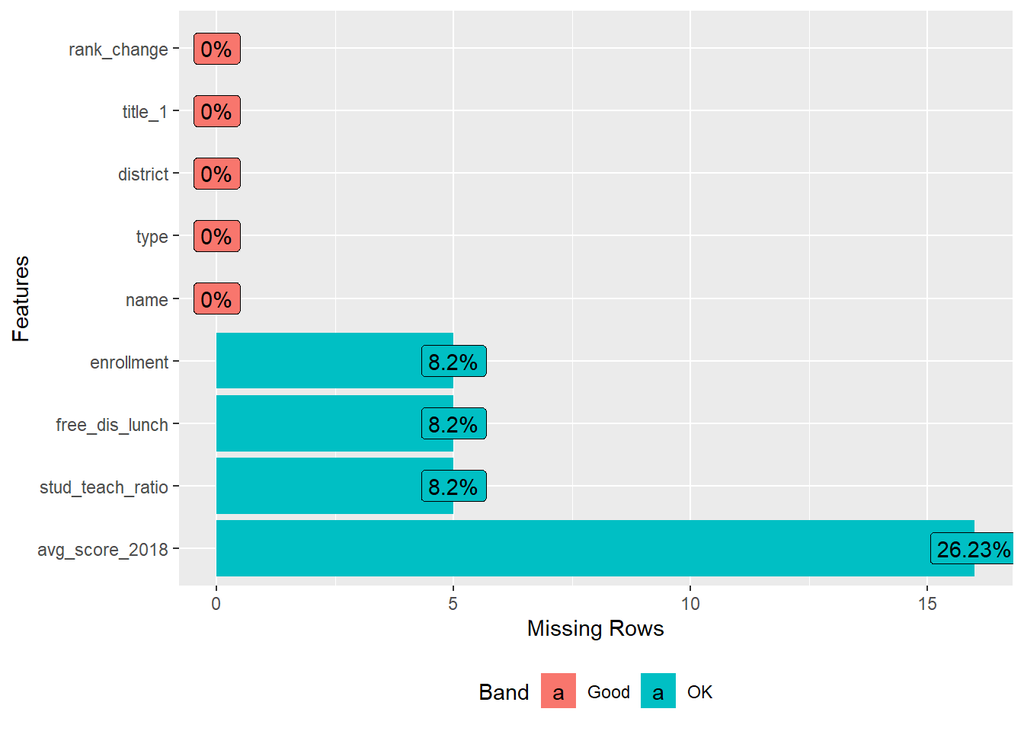

```r
plot_missing(schools_1)
```

### Let’s look at school performance by averages scores in 2018:

```r
mean(avg_score_2018 ~ name, data = schools_1, na.rm= TRUE)
```

```
##
##                                                           NaN
##                                                Asheville High
##                                                          61.9
##                                              Asheville Middle
##                                                          59.5
##                                      Avery's Creek Elementary
##                                                          51.6
##                                      Barnardsville Elementary
##                                                          72.2
##                                               Bell Elementary
##                                                          55.0
##                                     Black Mountain Elementary
##                                                          68.1
##                                        Black Mountain Primary
##                                                           NaN
##                                            Candler Elementary
##                                                          50.7
##                                             Cane Creek Middle
##                                                          83.0
##                                            Claxton Elementary
##                                                          66.2
##                                         Community High School
##                                                           7.0
##                data retrieved from school digger on 7/13/2019
##                                                           NaN
##                                                 Early College
##                                                           NaN
##                                            Eblen Intermediate
##                                                           NaN
##                                               Emma Elementary
##                                                          35.7
##                                                     Enka High
##                                                          61.7
##                                             Enka Intermediate
##                                                           NaN
##                                                   Enka Middle
##                                                          56.5
##                                                    Erwin High
##                                                          34.9
```

[output cut: 63 more lines]

```
##                                                           NaN
##                                         Valley Springs Middle
##                                                          71.9
##                                              Vance Elementary
##                                                          69.3
##                                        Weaverville Elementary
##                                                          82.1
##                                           Weaverville Primary
##                                                           NaN
##                                      West Buncombe Elementary
##                                                          79.1
##                                           Williams Elementary
##                                                          46.3
##                                            Woodfin Elementary
##                                                          31.4
```

### How does title I status affect enrollment figures? Let’s look at the boxplot of enrollment by title I status.

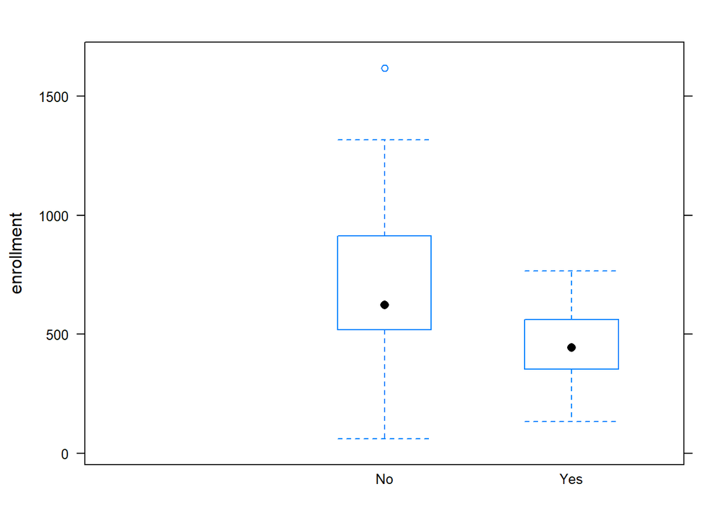

```r
bwplot(enrollment ~ title_1, data = schools_1, na.rm = TRUE)
```

### How do the different types of schools compare on state ranking?

Let’s look at rank change between 2017 and 2018 for public schools, public charter schools, and public magnet schools. We’ll first filter type:

```r
schools_1_type <- schools_1 %>%
  filter(type %in% c("Public", "Public, Magnet", "Public, Charter"))

favstats(rank_change ~ type, data = schools_1_type, na.rm = TRUE)
```

```
##              type  min      Q1 median     Q3 max       mean       sd  n
## 1          Public -166  -32.00   11.5  72.25 419   39.63158 130.5817 38
## 2 Public, Charter -327 -224.50 -122.0 -19.50  83 -122.00000 289.9138  2
## 3  Public, Magnet -448 -160.75    8.0  88.50 111  -80.25000 256.9376  4
##   missing
## 1       9
## 2       0
## 3       1
```

### To introduce multivariable thinking, we could use color or size to map a third (categorical) variable. For example, "How does enrollment affect the student teacher ratio by district?

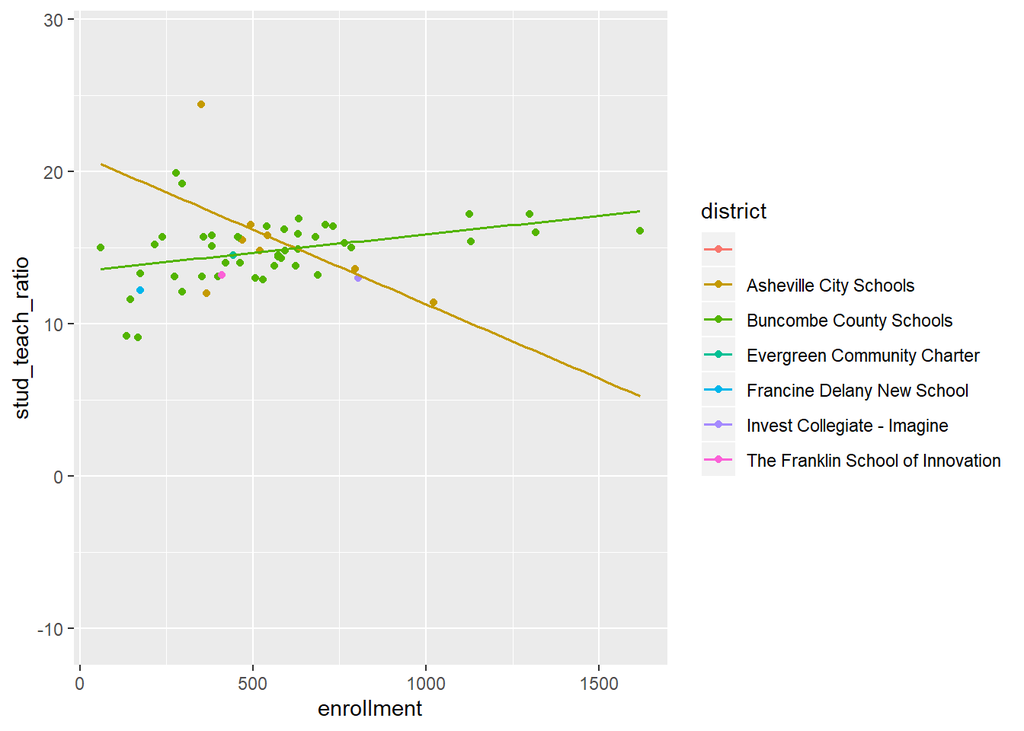

```r
gf_point(stud_teach_ratio ~ enrollment, data = schools_1, color = ~ district) %>%
  gf_lm()
```

```r
schools_1 %>%
  select(name, avg_score_2018) %>%
  arrange(desc(avg_score_2018))
```

```
##                                                             name
## 1                                    Evergreen Community Charter
## 2                                              Pisgah Elementary
## 3                                       Hominy Valley Elementary
## 4                            School of Inquiry and Life Sciences
## 5                                          Glen Arden Elementary
## 6                                              Cane Creek Middle
## 7                                           Haw Creek Elementary
## 8                                         Weaverville Elementary
## 9                                       West Buncombe Elementary
## 10                                           Fairview Elementary
## 11                                      Isaac Dickson Elementary
## 12                                                     Owen High
## 13                                      Barnardsville Elementary
## 14                                         Valley Springs Middle
```

[output cut: 109 more lines]

### Answer:

Evergreen Community Charter, Pisgah Elementary, Hominy Valley Elementary, School of Inquiry and Life Sciences, and Glen Arden Elementary.

### Let’s take a look at enrollment size and student-teacher ratio for these schools:

```r
top5 <- schools_1 %>%
  select(name, avg_score_2018, enrollment, stud_teach_ratio) %>%
  filter(name %in% c("Evergreen Community Charter", "Pisgah Elementary", "Hominy Valley Elementary", "School of Inquiry and Life Sciences", "Glen Arden Elementary"))
data.table(top5)
```

```
##                                   name avg_score_2018 enrollment
## 1:         Evergreen Community Charter           91.1        444
## 2:               Glen Arden Elementary           84.7        540
## 3:            Hominy Valley Elementary           86.2        381
## 4:                   Pisgah Elementary           90.3        175
## 5: School of Inquiry and Life Sciences           86.2        351
##    stud_teach_ratio
## 1:             14.5
## 2:             16.4
## 3:             15.1
## 4:             13.3
## 5:             24.4
```

### How do these same variables compare with the lowest five performing schools?

```r
schools_1 %>%
  select(name, avg_score_2018) %>%
  arrange(avg_score_2018)
```

```
##                                                             name
## 1                                            Johnston Elementary
## 2                                          Community High School
## 3                                              Oakley Elementary
## 4                                             Woodfin Elementary
## 5                                                   Erwin Middle
## 6                                                     Erwin High
## 7                                                Emma Elementary
## 8                                       Hall Fletcher Elementary
## 9                                            Williams Elementary
## 10                                            Candler Elementary
## 11                                      Avery's Creek Elementary
## 12                                          Leicester Elementary
## 13                                  Sand Hill-Venable Elementary
## 14                                               Bell Elementary
```

[output cut: 109 more lines]

```r
bottom5 <- schools_1 %>%
  select(name, avg_score_2018, enrollment, stud_teach_ratio) %>%
  filter(name %in% c("Johnston Elementary", "Community High School", "Oakley Elementary", "Woodfin Elementary", "Erwin Middle"))
data.table(bottom5)
```

```
##                     name avg_score_2018 enrollment stud_teach_ratio
## 1: Community High School            7.0        167              9.1
## 2:          Erwin Middle           33.0        688             13.2
## 3:   Johnston Elementary            6.7        296             12.1
## 4:     Oakley Elementary           22.5        463             15.6
## 5:    Woodfin Elementary           31.4        134              9.2
```

### Here is another way to filter the top and bottom values.

We will create a dataframe for the top and bottom 5 based on values rather than names and then bind the rows together.

```r
top5_scores <- schools_1 %>%
  select(name, avg_score_2018, enrollment, stud_teach_ratio) %>%
  top_n(5, avg_score_2018)

bottom5_scores <- schools_1 %>%
  select(name, avg_score_2018, enrollment, stud_teach_ratio) %>%
  top_n(-5, avg_score_2018)

top_bottom_5 <- bind_rows(top5_scores, bottom5_scores)

top_bottom_5 <- top_bottom_5 %>%
  arrange(desc(avg_score_2018))

data.table(top_bottom_5)
```

```
##                                    name avg_score_2018 enrollment
##  1:         Evergreen Community Charter           91.1        444
##  2:                   Pisgah Elementary           90.3        175
##  3:            Hominy Valley Elementary           86.2        381
##  4: School of Inquiry and Life Sciences           86.2        351
##  5:               Glen Arden Elementary           84.7        540
##  6:                        Erwin Middle           33.0        688
##  7:                  Woodfin Elementary           31.4        134
##  8:                   Oakley Elementary           22.5        463
##  9:               Community High School            7.0        167
## 10:                 Johnston Elementary            6.7        296
##     stud_teach_ratio
##  1:             14.5
##  2:             13.3
##  3:             15.1
##  4:             24.4
##  5:             16.4
##  6:             13.2
##  7:              9.2
##  8:             15.6
##  9:              9.1
## 10:             12.1
```

### Does it look like enrollment or student teacher ratio affects school performance?

Let’s visualize the data. First, we’ll look at enrollment and average scores.

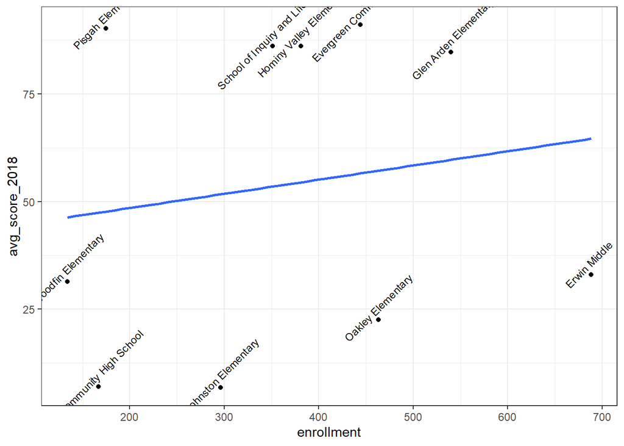

```r
ggplot(data = top_bottom_5, aes(enrollment, avg_score_2018, label= name)) +
  geom_point() +
  geom_smooth(method = "lm", se=FALSE) +
  geom_text(angle=45, size= 3, hjust= .4, vjust= -.6) +
  theme_bw()
```

### What about student teacher ratio?

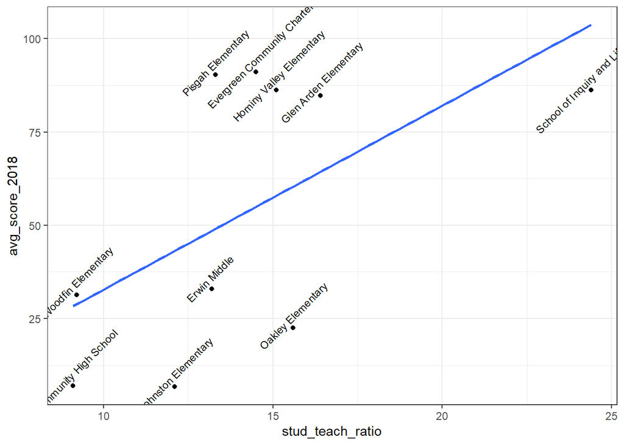

```r
ggplot(data = top_bottom_5, aes(stud_teach_ratio, avg_score_2018, label= name)) +
  geom_point() +
  geom_smooth(method = "lm", se=FALSE) +
  geom_text(angle=45, size= 3, hjust= .4, vjust= -.6) +
  theme_bw()
```

### What other variables do you think might affect school performance?

Let’s take a look at the percentage of students on free or reduced lunch.

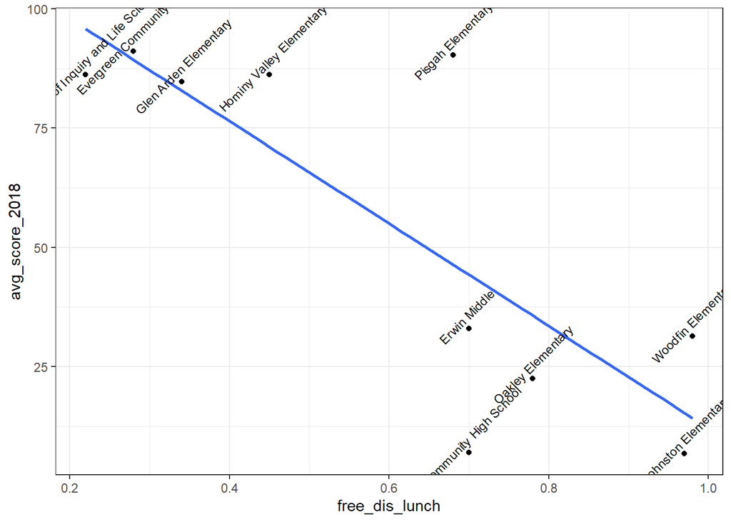

```r
top5_scores <- schools_1 %>%
  select(name, avg_score_2018, enrollment, stud_teach_ratio, free_dis_lunch) %>%
  top_n(5, avg_score_2018)


bottom5_scores <- schools_1 %>%
  select(name, avg_score_2018, enrollment, stud_teach_ratio, free_dis_lunch) %>%
  top_n(-5, avg_score_2018)

top_bottom_5 <- bind_rows(top5_scores, bottom5_scores)

top_bottom_5 <- top_bottom_5 %>%
  arrange(desc(avg_score_2018))

ggplot(data = top_bottom_5, aes(free_dis_lunch, avg_score_2018, label= name)) +
  geom_point() +
  geom_smooth(method = "lm", se=FALSE) +
  geom_text(angle=45, size= 3, hjust= .4, vjust= -.6) +
  theme_bw()
```